# Test of forecasting models

## All sites and drugs

### Drug A

#### Site A

##### Seasonality

###### Week

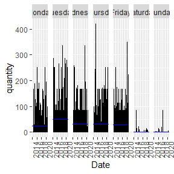

###### Year

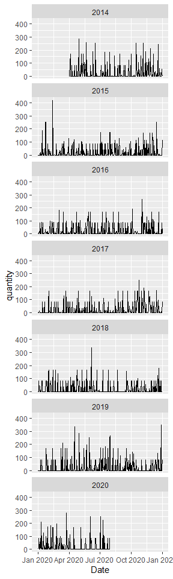

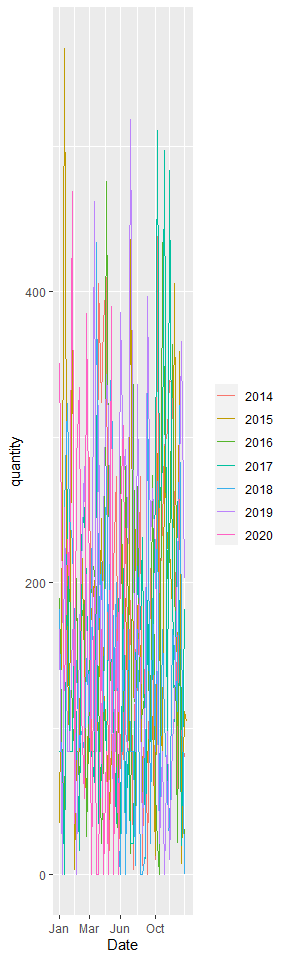

###### Raw data

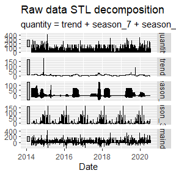

###### Detail of data

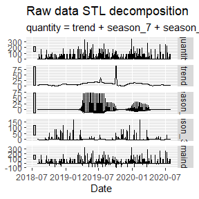

###### Weekly totals

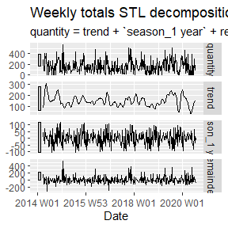

###### Detail of weekly totals

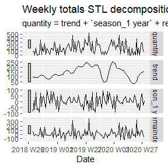

##### Residuals of STL model- raw data and weekly totals

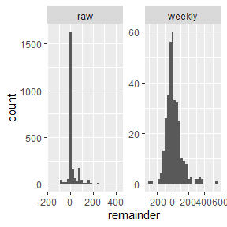

##### Simple exponential smoothing

| .model | term | estimate |
| --- | --- | --- |
| ETS(quantity ~ season(method = “N”)) | alpha | 0.0001002 |
| ETS(quantity ~ season(method = “N”)) | l[0] | 162.3565708 |

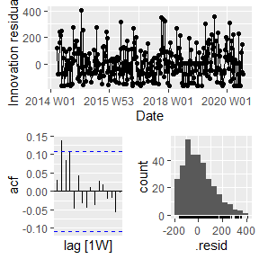

Ljung Box test for autocorrelation of residuals

| .model | lb_stat | lb_pvalue |
| --- | --- | --- |
| ETS(quantity ~ season(method = “N”)) | 17.63355 | 0.0614688 |

##### ARIMA

| .model | term | estimate | std.error | statistic | p.value |
| --- | --- | --- | --- | --- | --- |
| ARIMA(quantity) | ar1 | 0.6160404 | 0.1679880 | 3.667170 | 0.0002858 |
| ARIMA(quantity) | ma1 | -0.6055922 | 0.1698637 | -3.565165 | 0.0004173 |
| ARIMA(quantity) | ma2 | 0.1340922 | 0.0598298 | 2.241227 | 0.0256759 |
| ARIMA(quantity) | sar1 | 0.0981877 | 0.0639542 | 1.535282 | 0.1256726 |
| ARIMA(quantity) | constant | 56.3162905 | 3.3440977 | 16.840504 | 0.0000000 |

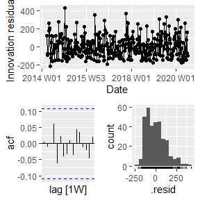

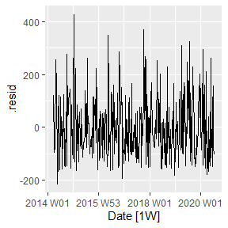

Ljung Box test for autocorrelation of residuals

| .model | lb_stat | lb_pvalue |
| --- | --- | --- |
| ARIMA(quantity) | 6.277749 | 0.7914132 |

##### Model testing

###### Weekly data

[figure not shown]

| .model | .type | ME | RMSE | MAE | MPE | MAPE | MASE | RMSSE |
| --- | --- | --- | --- | --- | --- | --- | --- | --- |
| ARIMA(quantity) | Test | -17.955 | 99.947 | 88.679 | -Inf | Inf | 0.71325 | 0.63442 |
| ETS(quantity ~ season(method = “N”)) | Test | -10.876 | 104.840 | 91.000 | -Inf | Inf | 0.73192 | 0.66546 |
| FASSTER(quantity ~ trend(1)) | Test | 45.033 | 113.580 | 91.000 | -Inf | Inf | 0.73192 | 0.72096 |
| prophet(quantity) | Test | 11.605 | 103.430 | 99.717 | -Inf | Inf | 0.80203 | 0.65653 |
| SNAIVE(quantity) | Test | -92.667 | 122.390 | 104.330 | -Inf | Inf | 0.83916 | 0.77687 |

###### Daily data

[figure not shown]

| .model | .type | ME | RMSE | MAE | MPE | MAPE | MASE | RMSSE |
| --- | --- | --- | --- | --- | --- | --- | --- | --- |
| ARIMA(quantity) | Test | -1.0351 | 54.794 | 36.070 | -Inf | Inf | 1.05120 | 0.84252 |
| ETS(quantity ~ season(method = “A”)) | Test | -1.9517 | 56.102 | 35.553 | -Inf | Inf | 1.03620 | 0.86265 |
| FASSTER(quantity ~ trend(1) + fourier(7)) | Test | -17.4840 | 58.755 | 45.809 | -Inf | Inf | 1.33510 | 0.90344 |
| prophet(quantity ~ season(7)) | Test | -2.7376 | 56.269 | 36.108 | -Inf | Inf | 1.05230 | 0.86521 |
| SNAIVE(quantity ~ lag(“week”)) | Test | -2.3333 | 57.196 | 25.667 | -Inf | Inf | 0.74802 | 0.87946 |

##### Cross validation

Cross validated accuracy for a variety of models using weekly data.

| .model | .type | ME | RMSE | MAE | MPE | MAPE | MASE | RMSSE | ACF1 |
| --- | --- | --- | --- | --- | --- | --- | --- | --- | --- |
| ARIMA(quantity) | Test | -12.8198993 | 124.7132 | 102.8648 | -Inf | Inf | 0.8375184 | 0.8005049 | -0.2324398 |
| ETS(quantity ~ season(method = “N”)) | Test | -4.5191525 | 123.5376 | 100.5418 | -Inf | Inf | 0.8186048 | 0.7929590 | -0.1909788 |
| FASSTER(quantity ~ trend(1)) | Test | -65.0342019 | 144.0960 | 123.1841 | -Inf | Inf | 1.0029574 | 0.9249186 | -0.0393517 |
| prophet(quantity) | Test | -6.6522803 | 140.3916 | 115.7322 | -Inf | Inf | 0.9422842 | 0.9011408 | 0.0362728 |
| SNAIVE(quantity) | Test | -0.1666667 | 166.2477 | 130.7917 | -Inf | Inf | 1.0648975 | 1.0671053 | 0.0135623 |

###### Cross validation- daily

Cross validated accuracy for a variety of models using daily data.

| .model | .type | ME | RMSE | MAE | MPE | MAPE | MASE | RMSSE | ACF1 |
| --- | --- | --- | --- | --- | --- | --- | --- | --- | --- |
| ARIMA(quantity) | Test | -12.151161 | 38.60934 | 28.46236 | -Inf | Inf | 0.8242388 | 0.5937153 | -0.0531722 |
| ETS(quantity ~ season(method = “A”)) | Test | -15.265937 | 37.59509 | 28.07931 | -Inf | Inf | 0.8131461 | 0.5781186 | -0.0773882 |
| FASSTER(quantity ~ trend(1) + fourier(7)) | Test | 8.258277 | 35.16723 | 20.55201 | NaN | Inf | 0.5951637 | 0.5407842 | -0.0782716 |
| prophet(quantity ~ season(7)) | Test | -16.997757 | 38.24398 | 29.49117 | -Inf | Inf | 0.8540320 | 0.5880969 | -0.0823807 |
| SNAIVE(quantity ~ lag(“week”)) | Test | -5.333333 | 56.33235 | 25.33333 | -Inf | Inf | 0.7336256 | 0.8662509 | -0.0092600 |

#### Site B

##### Seasonality

###### Week

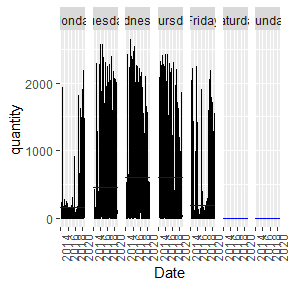

###### Year

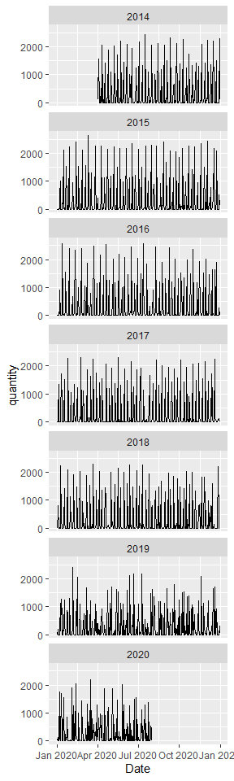

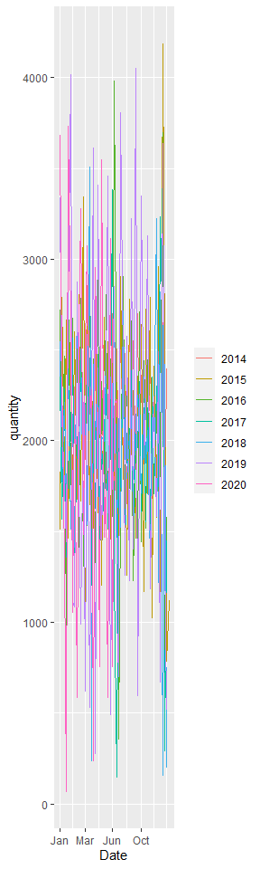

###### Raw data

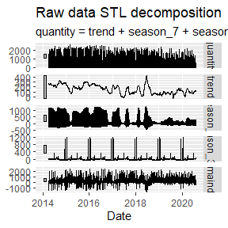

###### Detail of data

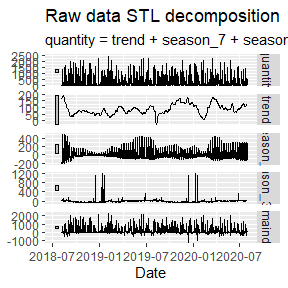

###### Weekly totals

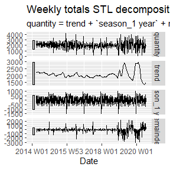

###### Detail of weekly totals

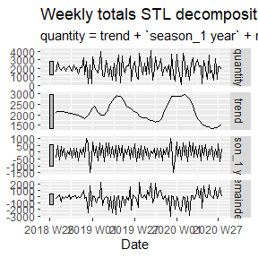

##### Residuals of STL model- raw data and weekly totals

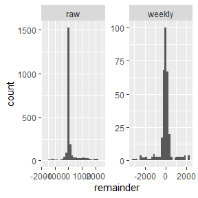

##### Simple exponential smoothing

| .model | term | estimate |
| --- | --- | --- |
| ETS(quantity ~ season(method = “N”)) | alpha | 0.0001 |
| ETS(quantity ~ season(method = “N”)) | l[0] | 2018.9770 |

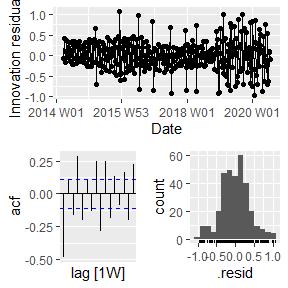

Ljung Box test for autocorrelation of residuals

| .model | lb_stat | lb_pvalue |
| --- | --- | --- |
| ETS(quantity ~ season(method = “N”)) | 271.4111 | 0 |

##### ARIMA

| .model | term | estimate | std.error | statistic | p.value |
| --- | --- | --- | --- | --- | --- |
| ARIMA(quantity) | ma1 | -1.5644956 | 0.0443110 | -35.307164 | 0.0000000 |
| ARIMA(quantity) | ma2 | 0.5815256 | 0.0442398 | 13.144845 | 0.0000000 |
| ARIMA(quantity) | sma1 | 0.1117924 | 0.0564947 | 1.978812 | 0.0486708 |

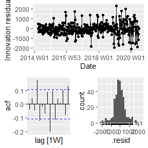

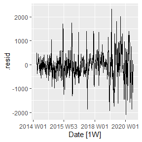

Ljung Box test for autocorrelation of residuals

| .model | lb_stat | lb_pvalue |
| --- | --- | --- |
| ARIMA(quantity) | 56.09459 | 0 |

##### Model testing

###### Weekly data

[figure not shown]

| .model | .type | ME | RMSE | MAE | MPE | MAPE | MASE | RMSSE |
| --- | --- | --- | --- | --- | --- | --- | --- | --- |
| ARIMA(quantity) | Test | -269.200 | 1095.30 | 815.82 | -74.093 | 93.163 | 1.3412 | 1.21480 |
| ETS(quantity ~ season(method = “N”)) | Test | -237.780 | 908.66 | 722.17 | -61.588 | 78.739 | 1.1873 | 1.00780 |
| FASSTER(quantity ~ trend(1)) | Test | -101.730 | 882.88 | 722.17 | -50.728 | 73.447 | 1.1873 | 0.97923 |
| prophet(quantity) | Test | -193.920 | 922.20 | 736.68 | -60.428 | 80.705 | 1.2111 | 1.02280 |
| SNAIVE(quantity) | Test | 10.833 | 1837.60 | 1650.20 | -83.329 | 150.260 | 2.7130 | 2.03820 |

###### Daily data

[figure not shown]

| .model | .type | ME | RMSE | MAE | MPE | MAPE | MASE | RMSSE |
| --- | --- | --- | --- | --- | --- | --- | --- | --- |
| ARIMA(quantity) | Test | -36.0820 | 434.43 | 347.90 | -Inf | Inf | 0.96973 | 0.62505 |
| ETS(quantity ~ season(method = “A”)) | Test | -8.8812 | 408.04 | 282.32 | NaN | Inf | 0.78695 | 0.58708 |
| FASSTER(quantity ~ trend(1) + fourier(7)) | Test | 235.1800 | 531.75 | 379.76 | NaN | Inf | 1.05850 | 0.76508 |
| prophet(quantity ~ season(7)) | Test | -5.2061 | 476.09 | 324.79 | NaN | Inf | 0.90532 | 0.68499 |
| SNAIVE(quantity ~ lag(“week”)) | Test | 185.2100 | 479.98 | 262.02 | -Inf | Inf | 0.73037 | 0.69059 |

##### Cross validation

Cross validated accuracy for a variety of models using weekly data.

| .model | .type | ME | RMSE | MAE | MPE | MAPE | MASE | RMSSE | ACF1 |
| --- | --- | --- | --- | --- | --- | --- | --- | --- | --- |
| ARIMA(quantity) | Test | 141.9050 | 1119.897 | 935.5436 | -81.45248 | 116.5322 | 1.562056 | 1.254452 | -0.3900158 |
| ETS(quantity ~ season(method = “N”)) | Test | 130.9735 | 1035.014 | 863.4654 | -84.11084 | 115.2071 | 1.441709 | 1.159371 | -0.3069377 |
| FASSTER(quantity ~ trend(1)) | Test | 175.0720 | 1101.875 | 948.1003 | -80.17792 | 116.6875 | 1.583022 | 1.234265 | -0.2019976 |
| prophet(quantity) | Test | 175.1060 | 1072.493 | 899.5316 | -84.38533 | 118.4566 | 1.501928 | 1.201353 | -0.2500828 |
| SNAIVE(quantity) | Test | 190.6875 | 1307.670 | 1035.2292 | -69.98942 | 113.6331 | 1.728499 | 1.464786 | -0.3973729 |

###### Cross validation- daily

Cross validated accuracy for a variety of models using daily data.

| .model | .type | ME | RMSE | MAE | MPE | MAPE | MASE | RMSSE | ACF1 |
| --- | --- | --- | --- | --- | --- | --- | --- | --- | --- |
| ARIMA(quantity) | Test | -6.314599 | 514.8799 | 362.1752 | -Inf | Inf | 1.0099517 | 0.7391462 | -0.0644588 |
| ETS(quantity ~ season(method = “A”)) | Test | -32.049368 | 491.9708 | 336.1137 | -Inf | Inf | 0.9372774 | 0.7062586 | -0.0991452 |
| FASSTER(quantity ~ trend(1) + fourier(7)) | Test | -132.485406 | 513.9743 | 391.2897 | -Inf | Inf | 1.0911394 | 0.7378462 | -0.0873330 |
| prophet(quantity ~ season(7)) | Test | -11.318184 | 495.9942 | 323.3268 | NaN | Inf | 0.9016202 | 0.7120345 | -0.0854999 |
| SNAIVE(quantity ~ lag(“week”)) | Test | -148.500000 | 611.1046 | 437.1667 | -Inf | Inf | 1.2190708 | 0.8772835 | -0.2450742 |

#### Site C

##### Seasonality

###### Week

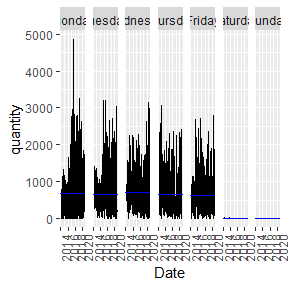

###### Year

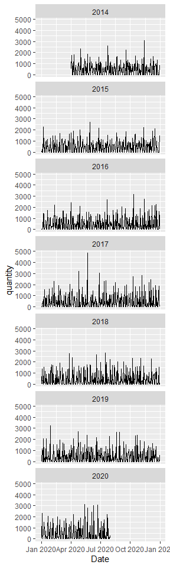

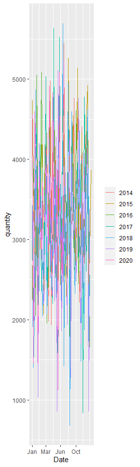

###### Raw data

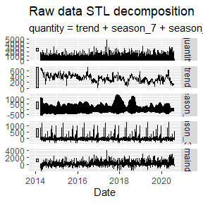

###### Detail of data

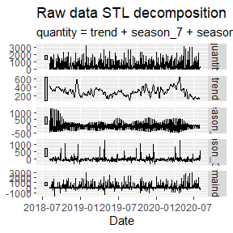

###### Weekly totals

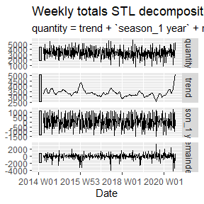

###### Detail of weekly totals

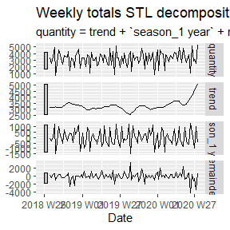

##### Residuals of STL model- raw data and weekly totals

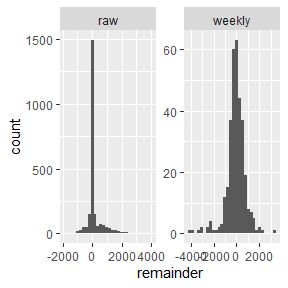

##### Simple exponential smoothing

| .model | term | estimate |
| --- | --- | --- |
| ETS(quantity ~ season(method = “N”)) | alpha | 0.0001 |
| ETS(quantity ~ season(method = “N”)) | l[0] | 3297.9622 |

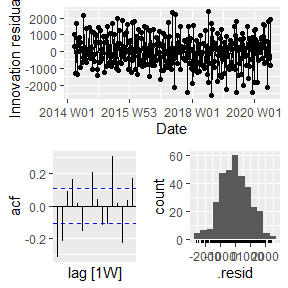

Ljung Box test for autocorrelation of residuals

| .model | lb_stat | lb_pvalue |
| --- | --- | --- |
| ETS(quantity ~ season(method = “N”)) | 159.7713 | 0 |

##### ARIMA

| .model | term | estimate | std.error | statistic | p.value |
| --- | --- | --- | --- | --- | --- |
| ARIMA(quantity) | ma1 | -1.5343538 | 0.0645112 | -23.7842942 | 0.0000000 |
| ARIMA(quantity) | ma2 | 0.5067446 | 0.1204304 | 4.2077801 | 0.0000333 |
| ARIMA(quantity) | ma3 | 0.0608475 | 0.0669502 | 0.9088467 | 0.3640964 |
| ARIMA(quantity) | sma1 | 0.3453082 | 0.0591670 | 5.8361659 | 0.0000000 |

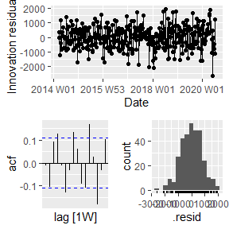

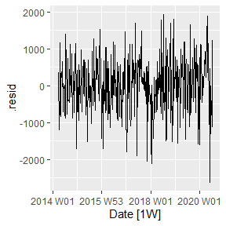

Ljung Box test for autocorrelation of residuals

| .model | lb_stat | lb_pvalue |
| --- | --- | --- |
| ARIMA(quantity) | 57.90608 | 0 |

##### Model testing

###### Weekly data

[figure not shown]

| .model | .type | ME | RMSE | MAE | MPE | MAPE | MASE | RMSSE |
| --- | --- | --- | --- | --- | --- | --- | --- | --- |
| ARIMA(quantity) | Test | -160.180 | 1592.4 | 1351.3 | -40.251 | 63.339 | 1.6235 | 1.4859 |
| ETS(quantity ~ season(method = “N”)) | Test | 14.938 | 1447.0 | 1225.5 | -29.304 | 53.342 | 1.4723 | 1.3502 |
| FASSTER(quantity ~ trend(1)) | Test | -183.680 | 1458.5 | 1291.7 | -37.091 | 58.562 | 1.5519 | 1.3609 |
| prophet(quantity) | Test | 117.140 | 1440.6 | 1222.2 | -23.818 | 49.767 | 1.4683 | 1.3442 |
| SNAIVE(quantity) | Test | 10.667 | 2195.8 | 1868.0 | -48.360 | 90.024 | 2.2443 | 2.0490 |

###### Daily data

[figure not shown]

| .model | .type | ME | RMSE | MAE | MPE | MAPE | MASE | RMSSE |
| --- | --- | --- | --- | --- | --- | --- | --- | --- |
| ARIMA(quantity) | Test | -21.0540 | 707.47 | 528.15 | -Inf | Inf | 1.24260 | 1.01140 |
| ETS(quantity ~ season(method = “A”)) | Test | -6.1685 | 653.88 | 438.91 | -Inf | Inf | 1.03260 | 0.93479 |
| FASSTER(quantity ~ trend(1) + fourier(7)) | Test | 354.1400 | 728.82 | 461.54 | Inf | Inf | 1.08590 | 1.04190 |
| prophet(quantity ~ season(7)) | Test | 9.5185 | 636.50 | 421.79 | NaN | Inf | 0.99233 | 0.90994 |
| SNAIVE(quantity ~ lag(“week”)) | Test | 303.1900 | 724.97 | 387.52 | -40.53 | 142.2 | 0.91172 | 1.03640 |

##### Cross validation

Cross validated accuracy for a variety of models using weekly data.

| .model | .type | ME | RMSE | MAE | MPE | MAPE | MASE | RMSSE | ACF1 |
| --- | --- | --- | --- | --- | --- | --- | --- | --- | --- |
| ARIMA(quantity) | Test | 101.68153 | 1070.105 | 878.7796 | -15.151884 | 38.97492 | 1.068348 | 1.011604 | -0.5428149 |
| ETS(quantity ~ season(method = “N”)) | Test | 27.84641 | 1073.538 | 864.4255 | -19.045617 | 40.06804 | 1.050897 | 1.014849 | -0.4386608 |
| FASSTER(quantity ~ trend(1)) | Test | 211.68458 | 1216.285 | 1029.0467 | -13.243619 | 43.34534 | 1.251030 | 1.149793 | -0.1285904 |
| prophet(quantity) | Test | 253.01411 | 1127.766 | 965.8663 | -10.249272 | 39.66578 | 1.174220 | 1.066113 | -0.3393385 |
| SNAIVE(quantity) | Test | 213.60417 | 1414.393 | 1084.1875 | -9.827629 | 42.51235 | 1.318065 | 1.337070 | -0.5216012 |

###### Cross validation- daily

Cross validated accuracy for a variety of models using daily data.

| .model | .type | ME | RMSE | MAE | MPE | MAPE | MASE | RMSSE | ACF1 |
| --- | --- | --- | --- | --- | --- | --- | --- | --- | --- |
| ARIMA(quantity) | Test | 62.90364 | 669.9151 | 489.9540 | -Inf | Inf | 1.1646896 | 0.9725089 | 0.0627889 |
| ETS(quantity ~ season(method = “A”)) | Test | 69.48203 | 626.7777 | 406.4979 | -Inf | Inf | 0.9663026 | 0.9098867 | -0.0031281 |
| FASSTER(quantity ~ trend(1) + fourier(7)) | Test | 164.92504 | 645.2205 | 428.8795 | NaN | Inf | 1.0195069 | 0.9366600 | -0.0123546 |
| prophet(quantity ~ season(7)) | Test | 87.48954 | 629.0975 | 409.5139 | NaN | Inf | 0.9734720 | 0.9132544 | -0.0109208 |
| SNAIVE(quantity ~ lag(“week”)) | Test | 86.45238 | 646.5062 | 365.5000 | -Inf | Inf | 0.8688448 | 0.9385264 | -0.2836529 |

### Drug B

Drug B is excluded from this analysis because there is only 3 years of data for Drug B. It may be included at a later date.

### Drug C

#### Site A

##### Seasonality

###### Week

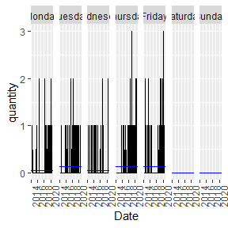

###### Year

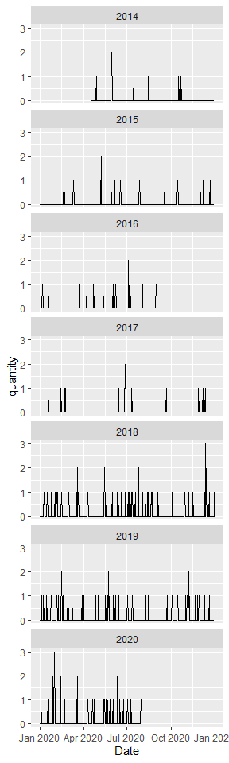

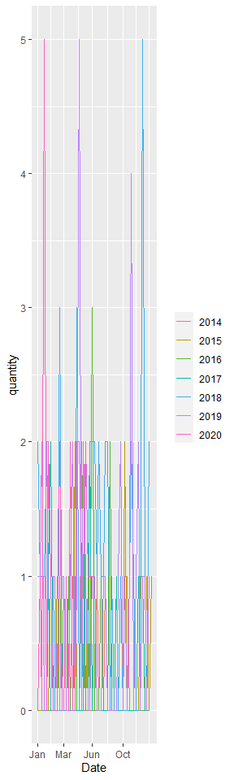

###### Raw data

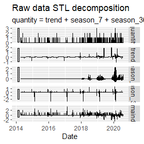

###### Detail of data

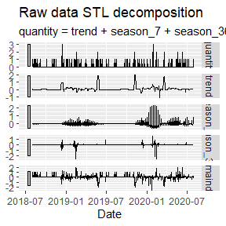

###### Weekly totals

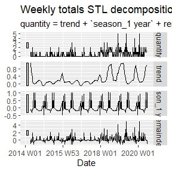

###### Detail of weekly totals

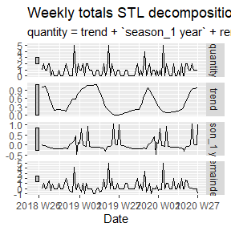

##### Residuals of STL model- raw data and weekly totals

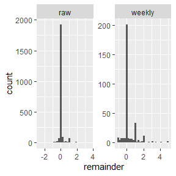

##### Simple exponential smoothing

| .model | term | estimate |
| --- | --- | --- |
| ETS(quantity ~ season(method = “N”)) | alpha | 0.0412606 |
| ETS(quantity ~ season(method = “N”)) | l[0] | 0.2623830 |

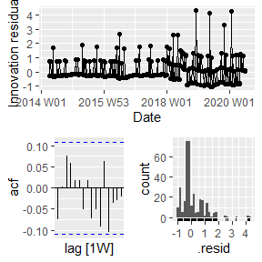

Ljung Box test for autocorrelation of residuals

| .model | lb_stat | lb_pvalue |
| --- | --- | --- |
| ETS(quantity ~ season(method = “N”)) | 17.77709 | 0.0588423 |

##### ARIMA

| .model | term | estimate | std.error | statistic | p.value |
| --- | --- | --- | --- | --- | --- |
| ARIMA(quantity) | ar1 | -0.0701466 | 0.0586881 | -1.195245 | 0.2328629 |
| ARIMA(quantity) | ma1 | -0.9615223 | 0.0226335 | -42.482203 | 0.0000000 |
| ARIMA(quantity) | constant | 0.0026204 | 0.0018765 | 1.396437 | 0.1635358 |

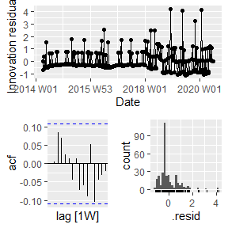

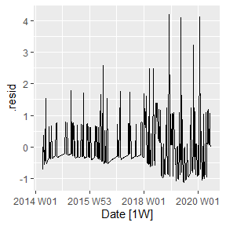

Ljung Box test for autocorrelation of residuals

| .model | lb_stat | lb_pvalue |
| --- | --- | --- |
| ARIMA(quantity) | 16.57448 | 0.084326 |